# Pyrogenic Carbon: Beetle-killed vs. fire-killed snags

Anna Talucci

12/3/2019

# Overview

The purpose of this study was to see if the amount / chemical structure of PyC that is produced during a forest fire depends on whether the trees were alive at the time of fire.

- Two samples (1. scorched bark and 2. charred wood from the base of the tree) were collected from each of three trees that had been killed by beetles prior to the Pole Creek Fire (PCF). Beetle kill was confirmed by evidence of J-shaped galleries under the bark.
- Two samples (1. Scorched bark and 2. Wood from under scorched bark @ base of tree) were collected from each of three trees that had been alive at the time of the fire.

Samples were dried O/N in oven at 50C on 6/20/18

PCF samples were ground in a ball grinder on 6/21/18 - NOTE: the scorched bark from Tree 4 and Tree 5 (live @ time of fire) still contained a good bit of sap residue. Ball grinding resulted in a tacky mashed up thing. Transfer to scin vial and dry @ 50C for an additional 3 days. Still seemed tacky and heterogeneous. Flash froze in liquid nitrogen and ground in mortar and pestle to a fine powder.

# Metadata

- jh.number: index number used for internal tracking
- name: sample name used during analysis
- field.fire: was the sample collected from the pole creek fire (PCF) or from the trees anna burned in the lab (lab)
- tree: individual tree number combined with the pcf/lab designation
- base: two of the samples anna burned in the lab were designated as ‘base’ - I’m not exactly sure what that means
- live.dead: was the tree alive or dead at the time of the fire / burning
- bark.char: was the sample from the bark or exposed char/wood under burned bark
- bpca.carbon: g total bpca / kg carbon
- bpca.soil: g total bpca / kg material
- b6.total: b6ca:total bpca ratio

# Packages

```r
library(ggplot2)
library(dplyr)
library(tidyr)
library(gridExtra)
library(lme4)
library(lsmeans)
library(statmod)
library(car)
library(DHARMa)
library(GGally)
library(MASS)
library(cowplot)
library(grid)
library(gtable)
```

# Data

```r
bk=read.csv("../data/beetle_kill.csv", header=TRUE,sep=",",na.strings=c("", "NA"))
```

## Pole Creak data

```r
pcf=subset(bk,field.fire=="PCF")
```

Add column for beetle-killed and fire-killed category

```r
pcf1 = pcf %>%
  mutate(kill_by = ifelse(live.dead=="dead", "beetle", "fire"))
pcf1
```

```
##    jh.number                                               name field.fire
## 1       6606 Beetle Kill 2018, PCF, Tree 1, Beetle Killed, Bark        PCF
## 2       6607 Beetle Kill 2018, PCF, Tree 1, Beetle Killed, Char        PCF
## 3       6608 Beetle Kill 2018, PCF, Tree 2, Beetle Killed, Bark        PCF
## 4       6609 Beetle Kill 2018, PCF, Tree 2, Beetle Killed, Char        PCF
## 5       6610 Beetle Kill 2018, PCF, Tree 3, Beetle Killed, Bark        PCF
## 6       6611 Beetle Kill 2018, PCF, Tree 3, Beetle Killed, Char        PCF
## 7       6612     Beetle Kill 2018, PCF, Tree 4, Live@Fire, Bark        PCF
## 8       6613     Beetle Kill 2018, PCF, Tree 4, Live@Fire, Wood        PCF
## 9       6614     Beetle Kill 2018, PCF, Tree 5, Live@Fire, Bark        PCF
## 10      6615     Beetle Kill 2018, PCF, Tree 5, Live@Fire, Wood        PCF
## 11      6616     Beetle Kill 2018, PCF, Tree 6, Live@Fire, Bark        PCF
## 12      6617     Beetle Kill 2018, PCF, Tree 6, Live@Fire, Wood        PCF
##     tree   base live.dead live.dead.edit bark.char bpca.carbon bpca.soil
## 1  pcf.1 nobase      dead           dead      Bark       12.40      8.02
```

[output cut: 24 more lines]

# Data Visualization

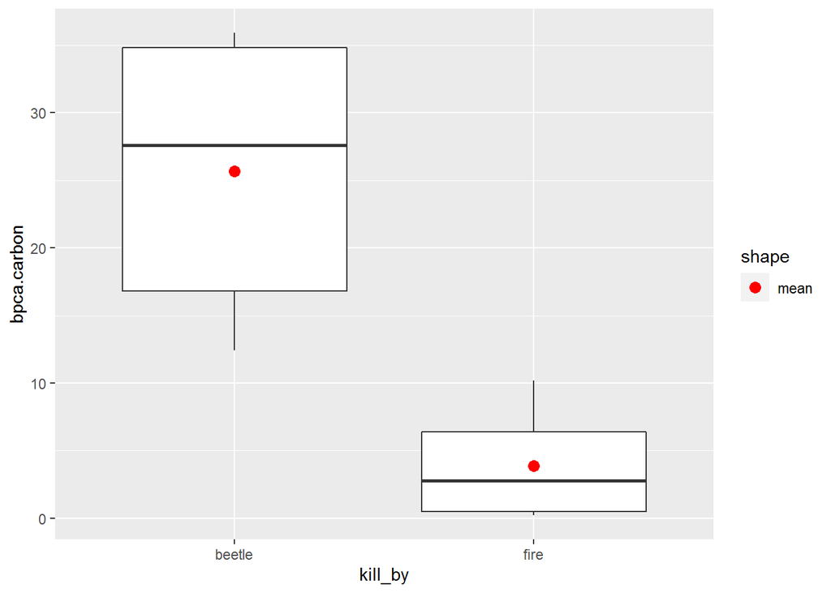

```r
qplot(x = kill_by, y = bpca.carbon, data = pcf1, geom = "boxplot") +
stat_summary(fun = mean, aes(shape = "mean"), geom = "point", color = "red", size = 3)
```

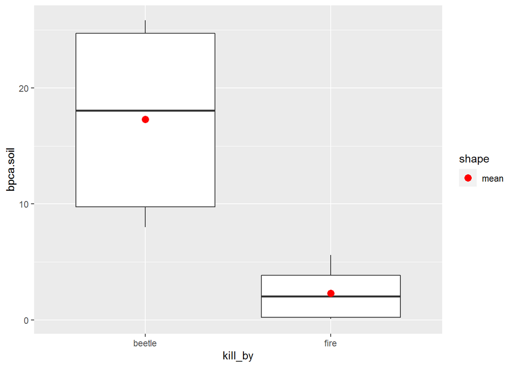

```r
qplot(x = kill_by, y = bpca.soil, data = pcf1, geom = "boxplot") +
stat_summary(fun = mean, aes(shape = "mean"), geom = "point", color = "red", size = 3)
```

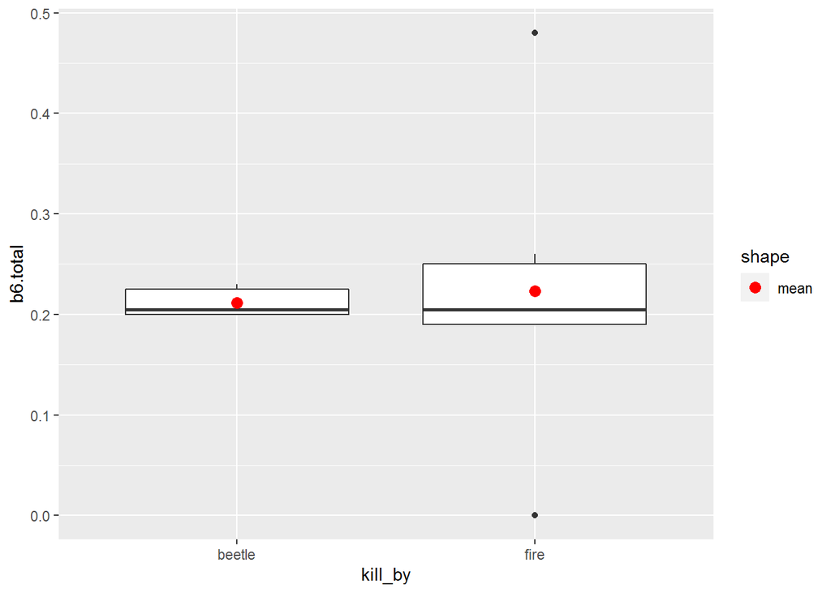

```r
qplot(x = kill_by, y = b6.total, data = pcf1, geom = "boxplot") +
stat_summary(fun = mean, aes(shape = "mean"), geom = "point", color = "red", size = 3)
```

# Analysis

Analyses were performed with linear models. We used a Welch t-test with unequal variance to test for a difference in means between beetle-killed and fire-killed snags.

### BPCA carbon

#### Summary data

```r
( sumdat1 = summarise( group_by(pcf1, "Mortality agent" = kill_by),
n = n(),
Mean = mean(bpca.carbon),
SD = sd(bpca.carbon),
Median = median(bpca.carbon),
Minimum = min(bpca.carbon),
Maximum = max(bpca.carbon) ) )
```

```
## # A tibble: 2 x 7
##   `Mortality agent`     n  Mean    SD Median Minimum Maximum
##   <chr>             <int> <dbl> <dbl>  <dbl>   <dbl>   <dbl>
## 1 beetle                6 25.6  10.6   27.6     12.4    35.9
## 2 fire                  6  3.87  4.14   2.78     0.2    10.2
```

#### Model

```r
fit1 = lm(bpca.carbon ~ kill_by, data = pcf1)
```

#### Residuals

```r
# Get the fitted value for each observation
pcf1$fit1 = fitted(fit1)
# Get the residuals of the model
pcf1$res1 = residuals(fit1)
```

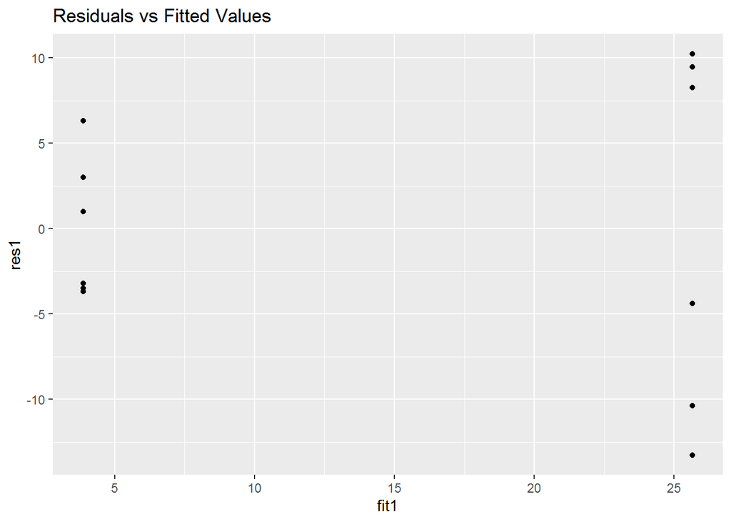

```r
qplot(x = fit1, y = res1, data = pcf1,
main = "Residuals vs Fitted Values")
```

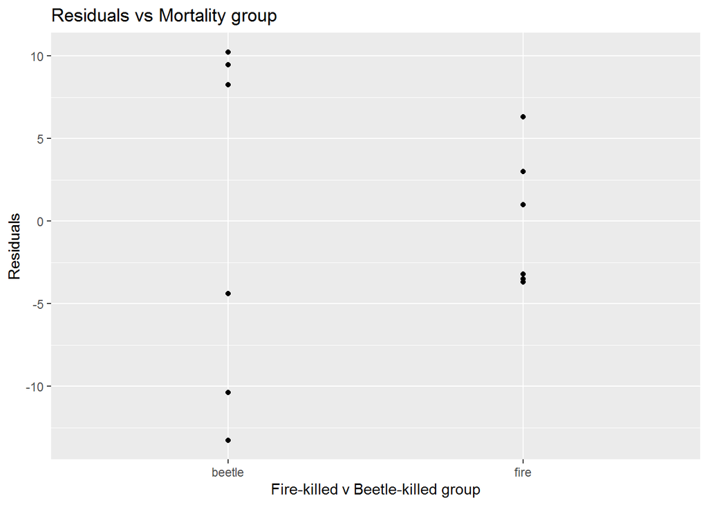

```r
qplot(x = kill_by, y = res1, data = pcf1,
xlab = "Fire-killed v Beetle-killed group",
ylab = "Residuals",
main = "Residuals vs Mortality group")
```

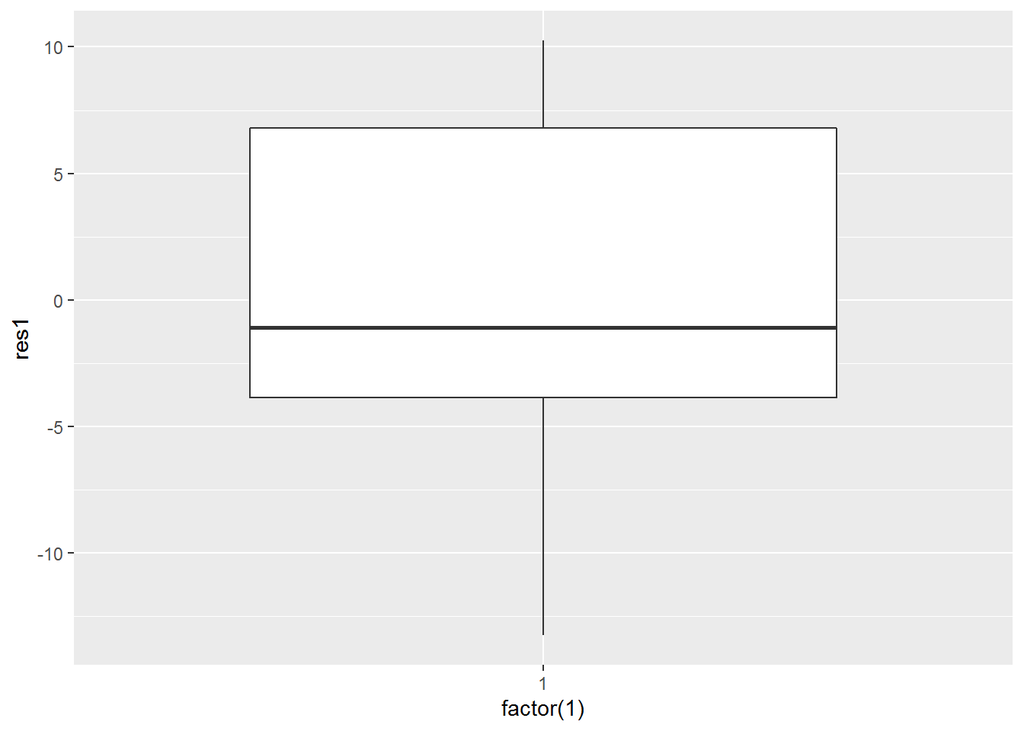

```r
qplot(x = factor(1), y = res1, data = pcf1, geom = "boxplot")
```

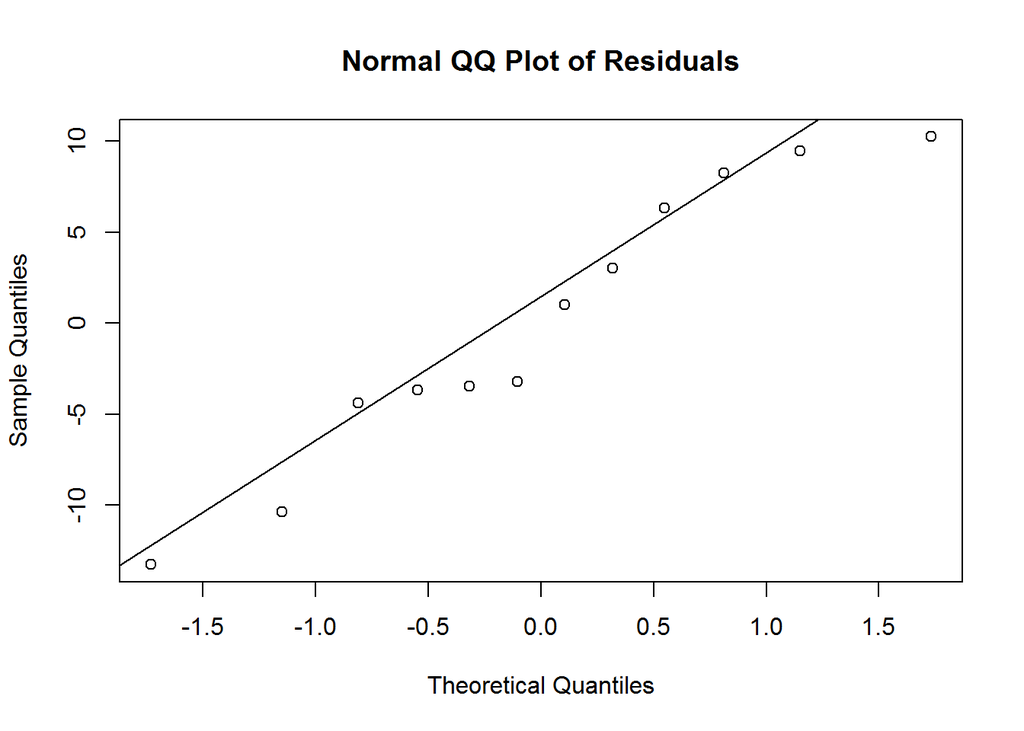

```r
qqnorm(pcf1$res1, main = "Normal QQ Plot of Residuals")
qqline(pcf1$res1) # add reference line to the qq plot
```

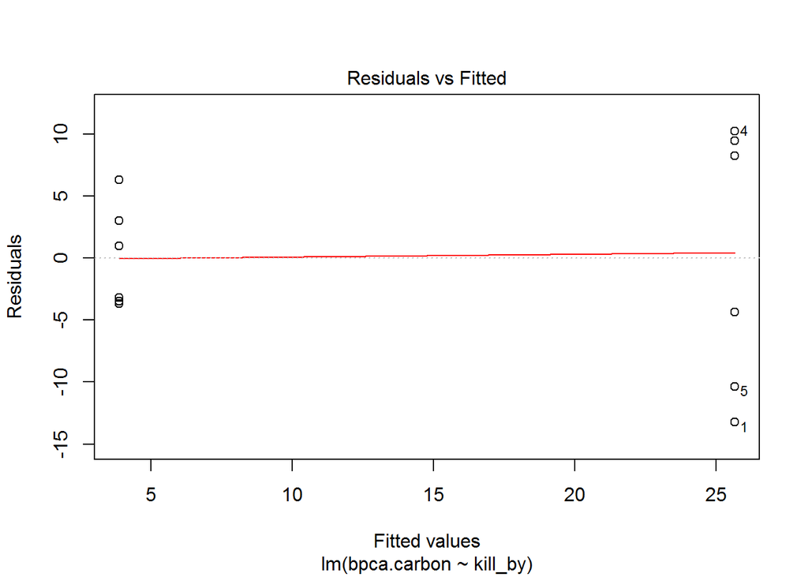

```r
plot(fit1, which = 1) # residual vs fitted values
```

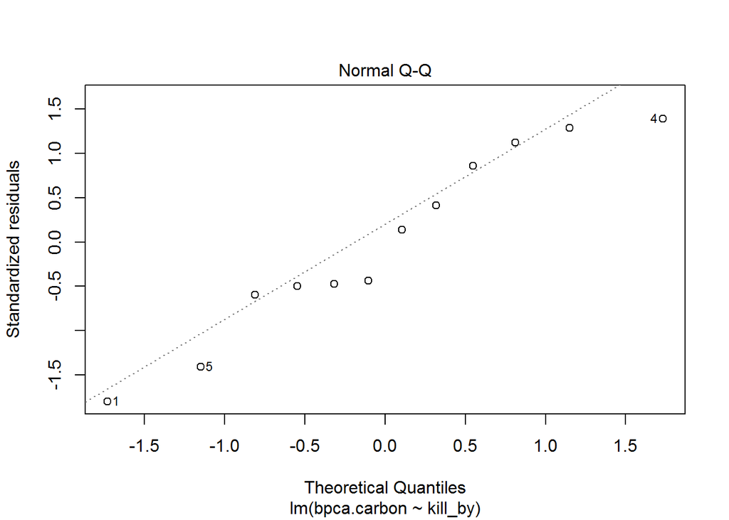

```r
plot(fit1, which = 2) # qqnorm plot of residuals
```

#### Model Summary

```r
summary(fit1)
```

```
##
## Call:
## lm(formula = bpca.carbon ~ kill_by, data = pcf1)
##
## Residuals:
##     Min      1Q  Median      3Q     Max
## -13.250  -3.848  -1.093   6.803  10.250
##
## Coefficients:
##             Estimate Std. Error t value Pr(>|t|)
## (Intercept)   25.650      3.293   7.789 1.49e-05 ***
## kill_byfire  -21.777      4.657  -4.676 0.000873 ***
## ---
## Signif. codes:  0 '***' 0.001 '**' 0.01 '*' 0.05 '.' 0.1 ' ' 1
##
## Residual standard error: 8.067 on 10 degrees of freedom
## Multiple R-squared:  0.6862, Adjusted R-squared:  0.6548
## F-statistic: 21.86 on 1 and 10 DF,  p-value: 0.0008731
```

```r
data.frame(summary(lsmeans(fit1, pairwise ~ kill_by),type = "response"))
```

```
##   lsmeans.kill_by lsmeans.lsmean lsmeans.SE lsmeans.df lsmeans.lower.CL
## 1          beetle      25.650000   3.293247         10        18.312187
## 2            fire       3.873333   3.293247         10        -3.464479
##   lsmeans.upper.CL contrasts.contrast contrasts.estimate contrasts.SE
## 1         32.98781      beetle - fire           21.77667     4.657355
## 2         11.21115      beetle - fire           21.77667     4.657355
##   contrasts.df contrasts.t.ratio contrasts.p.value
## 1           10          4.675758      0.0008731269
## 2           10          4.675758      0.0008731269
```

#### t-test

```r
( respunequal = t.test(bpca.carbon ~ kill_by, data = pcf1) )
```

```
##
##  Welch Two Sample t-test
##
## data:  bpca.carbon by kill_by
## t = 4.6758, df = 6.4839, p-value = 0.002783
## alternative hypothesis: true difference in means is not equal to 0
## 95 percent confidence interval:
##  10.58357 32.96977
## sample estimates:
## mean in group beetle   mean in group fire
##            25.650000             3.873333
```

##### Table of estimates

“g BPCA /material”

```r
# Write out the results from the two-sample t-test with unequal variances
# A title for the test
titleres = as.character(expression(bold("Welch"~t-test*~"for"~a~difference*~"in"~means)))
# This is the t stat with df and p-value
ttestres1 = as.character(expression(t[6.5]==-4.7*","~italic(p)==0.003))
# The estimated difference in group means (I calculated from the test results)
diff1 = as.character(expression(Delta==21.8~g~BPCA~kg~C^-1))
# The 95% CI of the difference
ci1 = as.character(expression(95*"%"~CI*":"~10.6~to~33.0))
# Put these into a single column of a data.frame
d1 = data.frame(col = rbind(ttestres1, diff1, ci1) )
```

```r
t1 = tableGrob(d1, rows = NULL, cols = NULL,
theme = ttheme_default(core = list(bg_params = list(fill = "white"),
fg_params = list(parse = TRUE),
padding = unit(c(2.5, 2.5), "mm"))))
```

```r
t1 = gtable_add_grob(t1, grobs = rectGrob(gp = gpar(fill = NA, lwd = NA)),
t = 1, b = nrow(t1), r = ncol(t1), l = 1)
```

#### Graph

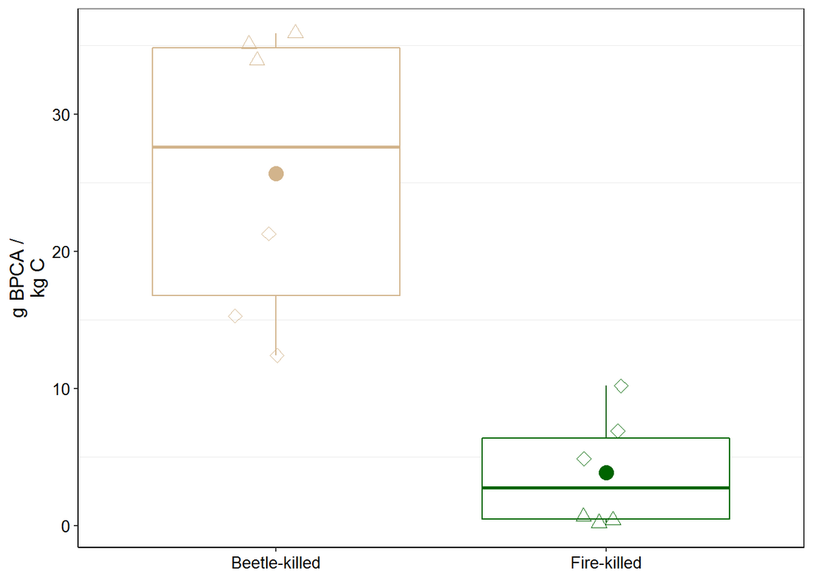

```r
g1 = ggplot(pcf1, aes(x = kill_by, y = bpca.carbon, color=kill_by) ) + # define plot axes
  geom_boxplot(outlier.shape = NA) + # Add boxplots for each group
  geom_point(aes(color = kill_by, shape = bark.char), size = 3, position = position_jitter(w = 0.15, h = 0, seed=10)) +
stat_summary(fun = mean, geom= "point", size = 4) + # Add means to the plot
  scale_shape_manual(values = c(23, 24)) +
  labs(x=(NULL), y= "g BPCA /\nkg C") +

  scale_color_manual(values = c("tan", "darkgreen")) +
  scale_x_discrete(labels= c("Beetle-killed", "Fire-killed")) +
  theme_bw() +
  theme(legend.position = "none") +
theme(panel.grid.major = element_blank()) +
    theme(axis.title.y = element_text(size = 12, hjust = 0.5, vjust = 1.1),
        axis.text.x = element_text(size = 10, color = "black"),
        axis.text.y = element_text(size = 10, color = "black"),
        axis.line = element_line(colour = "black"))


g1
```

### BPCA Mass

#### Summary data

```r
( sumdat2 = summarise( group_by(pcf1, "Mortality agent" = kill_by),
n = n(),
Mean = mean(bpca.soil),
SD = sd(bpca.soil),
Median = median(bpca.soil),
Minimum = min(bpca.soil),
Maximum = max(bpca.soil) ) )
```

```
## # A tibble: 2 x 7
##   `Mortality agent`     n  Mean    SD Median Minimum Maximum
##   <chr>             <int> <dbl> <dbl>  <dbl>   <dbl>   <dbl>
## 1 beetle                6 17.3   8.41  18.1     8.02   25.8
## 2 fire                  6  2.31  2.40   2.03    0.09    5.59
```

#### Model

```r
fit2 = lm(bpca.soil ~ kill_by, data = pcf1)
```

```r
head(pcf1)
```

```
##   jh.number                                               name field.fire  tree
## 1      6606 Beetle Kill 2018, PCF, Tree 1, Beetle Killed, Bark        PCF pcf.1
## 2      6607 Beetle Kill 2018, PCF, Tree 1, Beetle Killed, Char        PCF pcf.1
## 3      6608 Beetle Kill 2018, PCF, Tree 2, Beetle Killed, Bark        PCF pcf.2
## 4      6609 Beetle Kill 2018, PCF, Tree 2, Beetle Killed, Char        PCF pcf.2
## 5      6610 Beetle Kill 2018, PCF, Tree 3, Beetle Killed, Bark        PCF pcf.3
## 6      6611 Beetle Kill 2018, PCF, Tree 3, Beetle Killed, Char        PCF pcf.3
##     base live.dead live.dead.edit bark.char bpca.carbon bpca.soil b6.total
## 1 nobase      dead           dead      Bark       12.40      8.02     0.20
## 2 nobase      dead           dead      Wood       33.91     25.10     0.23
## 3 nobase      dead           dead      Bark       21.28     12.55     0.20
## 4 nobase      dead           dead      Wood       35.90     25.82     0.23
## 5 nobase      dead           dead      Bark       15.29      8.81     0.20
## 6 nobase      dead           dead      Wood       35.12     23.56     0.21
##   kill_by  fit1   res1
## 1  beetle 25.65 -13.25
## 2  beetle 25.65   8.26
## 3  beetle 25.65  -4.37
## 4  beetle 25.65  10.25
## 5  beetle 25.65 -10.36
## 6  beetle 25.65   9.47
```

#### Residuals

```r
# Get the fitted value for each observation
pcf1$fit2 = fitted(fit2)
# Get the residuals of the model
pcf1$res2 = residuals(fit2)
```

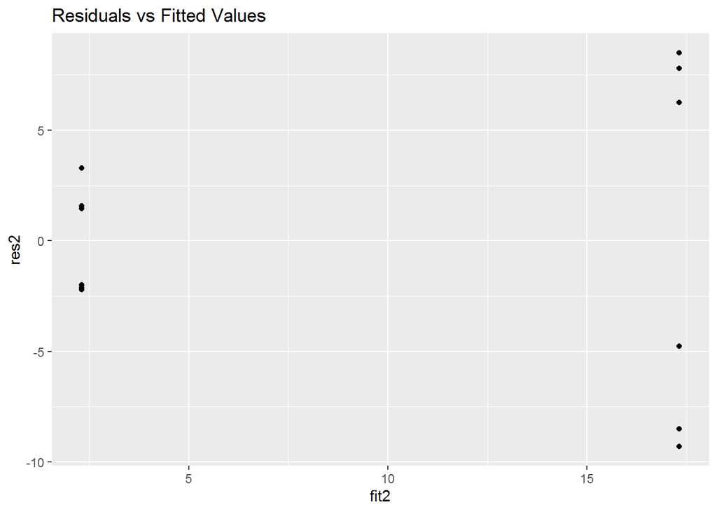

```r
qplot(x = fit2, y = res2, data = pcf1,
main = "Residuals vs Fitted Values")
```

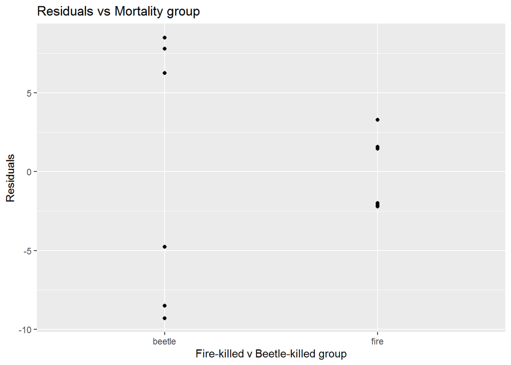

```r
qplot(x = kill_by, y = res2, data = pcf1,
xlab = "Fire-killed v Beetle-killed group",
ylab = "Residuals",
main = "Residuals vs Mortality group")
```

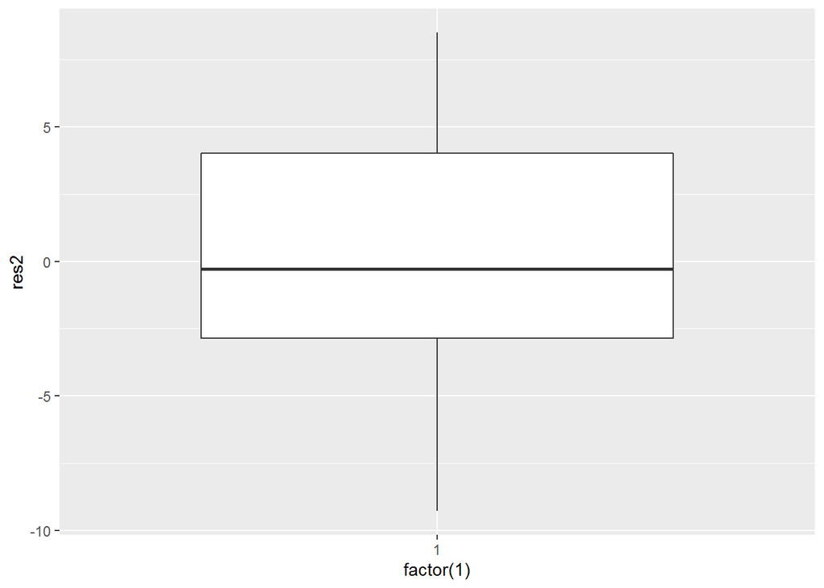

```r
qplot(x = factor(1), y = res2, data = pcf1, geom = "boxplot")
```

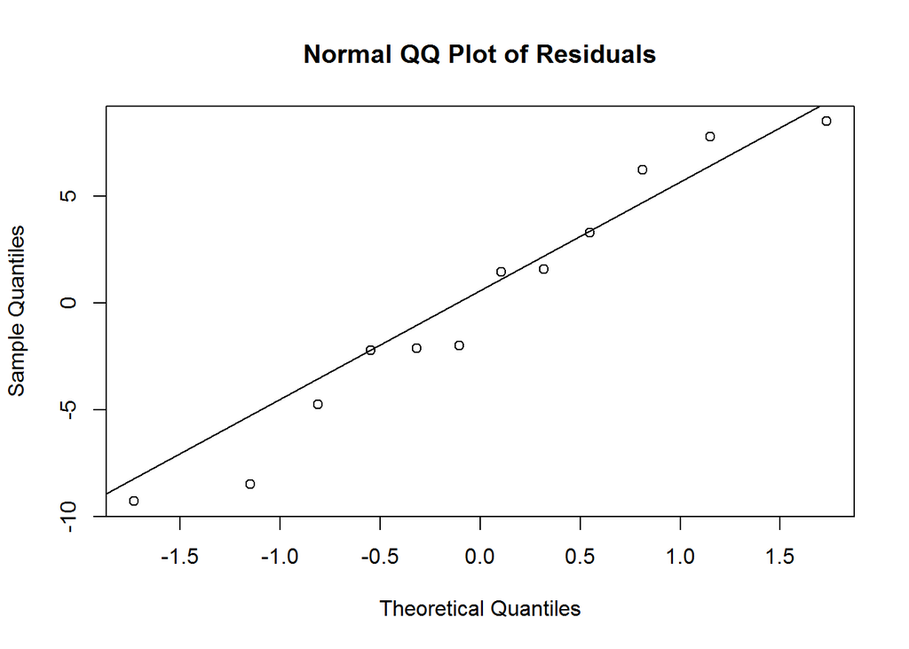

```r
qqnorm(pcf1$res2, main = "Normal QQ Plot of Residuals")
qqline(pcf1$res2) # add reference line to the qq plot
```

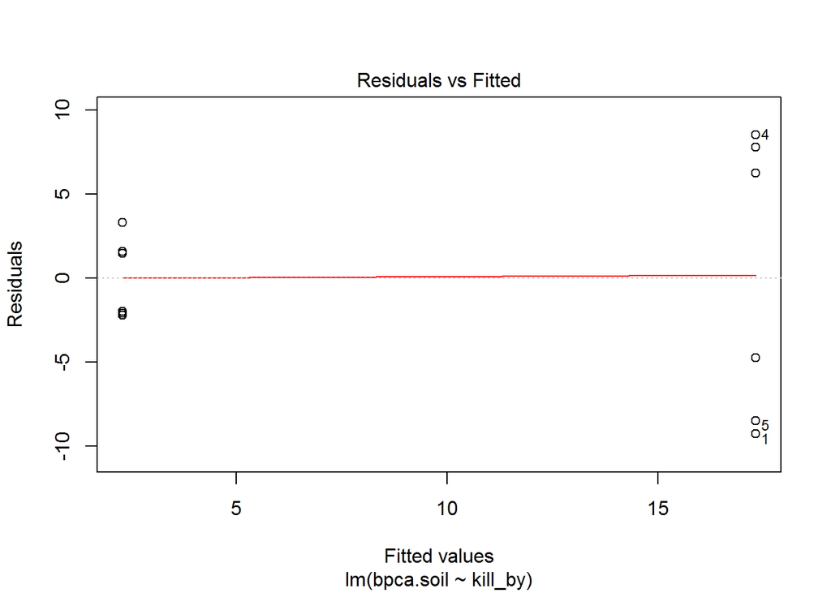

```r
plot(fit2, which = 1) # residual vs fitted values
```

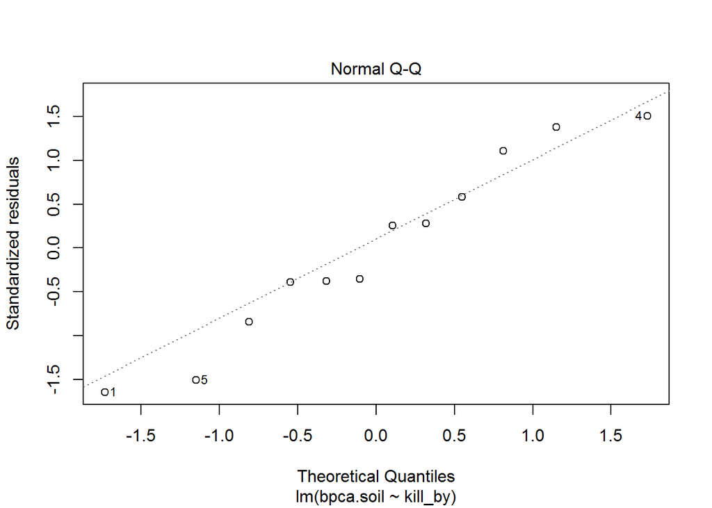

```r
plot(fit2, which = 2) # qqnorm plot of residuals
```

#### Model Summary

```r
summary(fit2)
```

```
##
## Call:
## lm(formula = bpca.soil ~ kill_by, data = pcf1)
##
## Residuals:
##    Min     1Q Median     3Q    Max
## -9.290 -2.851 -0.270  4.026  8.510
##
## Coefficients:
##             Estimate Std. Error t value Pr(>|t|)
## (Intercept)   17.310      2.524   6.859 4.41e-05 ***
## kill_byfire  -15.005      3.569  -4.204  0.00182 **
## ---
## Signif. codes:  0 '***' 0.001 '**' 0.01 '*' 0.05 '.' 0.1 ' ' 1
##
## Residual standard error: 6.182 on 10 degrees of freedom
## Multiple R-squared:  0.6387, Adjusted R-squared:  0.6025
## F-statistic: 17.67 on 1 and 10 DF,  p-value: 0.001817
```

```r
data.frame(summary(lsmeans(fit2, pairwise ~ kill_by),type = "response"))
```

```
##   lsmeans.kill_by lsmeans.lsmean lsmeans.SE lsmeans.df lsmeans.lower.CL
## 1          beetle         17.310   2.523748         10        11.686738
## 2            fire          2.305   2.523748         10        -3.318262
##   lsmeans.upper.CL contrasts.contrast contrasts.estimate contrasts.SE
## 1        22.933262      beetle - fire             15.005     3.569119
## 2         7.928262      beetle - fire             15.005     3.569119
##   contrasts.df contrasts.t.ratio contrasts.p.value
## 1           10          4.204119       0.001816787
## 2           10          4.204119       0.001816787
```

#### t-test

```r
( fit2_respunequal = t.test(bpca.soil ~ kill_by, data = pcf1) )
```

```
##
##  Welch Two Sample t-test
##
## data:  bpca.soil by kill_by
## t = 4.2041, df = 5.8091, p-value = 0.006081
## alternative hypothesis: true difference in means is not equal to 0
## 95 percent confidence interval:
##   6.201621 23.808379
## sample estimates:
## mean in group beetle   mean in group fire
##               17.310                2.305
```

##### Table

“g BPCA /material”

```r
# Write out the results from the two-sample t-test with unequal variances
# A title for the test
titleres = as.character(expression(bold("Welch"~t-test*~"for"~a~difference*~"in"~means)))
# This is the t stat with df and p-value
ttestres2 = as.character(expression(t[5.8]==-4.2*","~italic(p)==0.006))
# The estimated difference in group means (I calculated from the test results)
diff2 = as.character(expression(Delta==15.0~g~BPCA~kg~material^-1))
# The 95% CI of the difference
ci2 = as.character(expression(95*"%"~CI*":"~6.2~to~23.8))
# Put these into a single column of a data.frame
d2 = data.frame(col = rbind(ttestres2, diff2, ci2) )
```

```r
t2 = tableGrob(d2, rows = NULL, cols = NULL,
theme = ttheme_default(core = list(bg_params = list(fill = "white"),
fg_params = list(parse = TRUE),
padding = unit(c(2.5, 2.5), "mm"))))
```

```r
t2 = gtable_add_grob(t2, grobs = rectGrob(gp = gpar(fill = NA, lwd = NA)),
t = 1, b = nrow(t2), r = ncol(t2), l = 1)
```

#### Graph

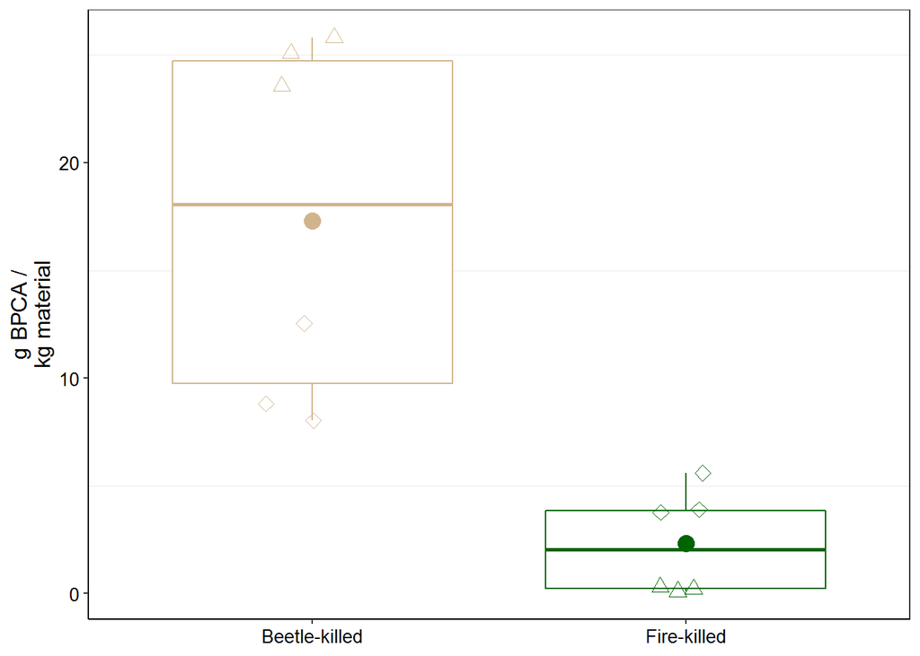

```r
g2 = ggplot(pcf1, aes(x = kill_by, y = bpca.soil, color=kill_by) ) + # define plot axes
  geom_boxplot(outlier.shape = NA) + # Add boxplots for each group
  geom_point(aes(color = kill_by, shape = bark.char), size = 3, position = position_jitter(w = 0.15, h = 0, seed=10)) +
stat_summary(fun = mean, geom= "point", size = 4) + # Add means to the plot
  scale_shape_manual(values = c(23, 24)) +
  labs(x=(NULL), y= "g BPCA /\nkg material") +

  scale_color_manual(values = c("tan", "darkgreen")) +
  scale_x_discrete(labels= c("Beetle-killed", "Fire-killed")) +
  theme_bw() +
  theme(legend.position = "none") +
theme(panel.grid.major = element_blank()) +
    theme(axis.title.y = element_text(size = 12, hjust = 0.5, vjust = 1.1),
        axis.text.x = element_text(size = 10, color = "black"),
        axis.text.y = element_text(size = 10, color = "black"),
        axis.line = element_line(colour = "black"))


g2
```

### B6CA Total

#### Summary data

```r
( sumdat3 = summarise( group_by(pcf1, "Mortality agent" = kill_by),
n = n(),
Mean = mean(b6.total),
SD = sd(b6.total),
Median = median(b6.total),
Minimum = min(b6.total),
Maximum = max(b6.total) ) )
```

```
## # A tibble: 2 x 7
##   `Mortality agent`     n  Mean     SD Median Minimum Maximum
##   <chr>             <int> <dbl>  <dbl>  <dbl>   <dbl>   <dbl>
## 1 beetle                6 0.212 0.0147  0.205     0.2    0.23
## 2 fire                  6 0.223 0.154   0.205     0      0.48
```

#### Model

```r
fit3 = lm(b6.total ~ kill_by, data = pcf1)
```

#### Residuals

```r
# Get the fitted value for each observation
pcf1$fit3 = fitted(fit3)
# Get the residuals of the model
pcf1$res3 = residuals(fit3)
```

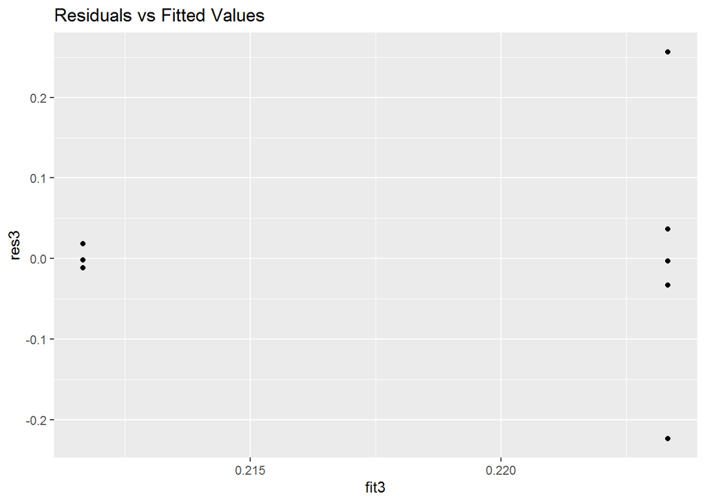

```r
qplot(x = fit3, y = res3, data = pcf1,
main = "Residuals vs Fitted Values")
```

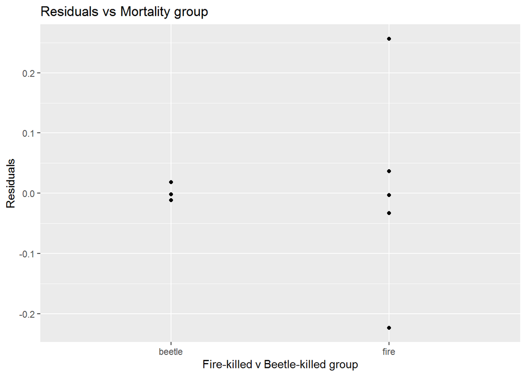

```r
qplot(x = kill_by, y = res3, data = pcf1,
xlab = "Fire-killed v Beetle-killed group",
ylab = "Residuals",
main = "Residuals vs Mortality group")
```

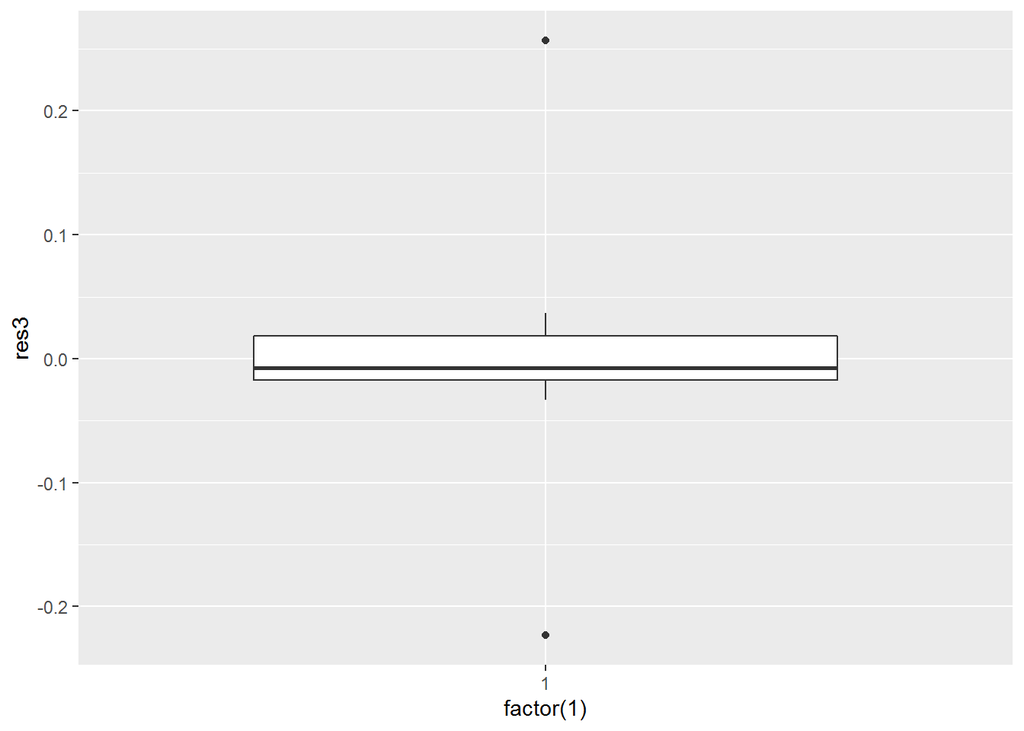

```r
qplot(x = factor(1), y = res3, data = pcf1, geom = "boxplot")
```

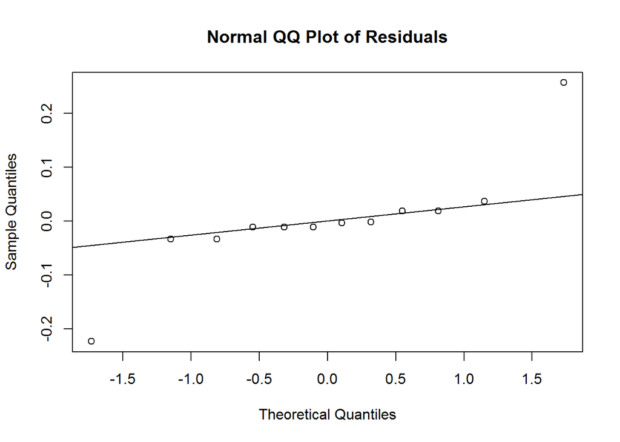

```r
qqnorm(pcf1$res3, main = "Normal QQ Plot of Residuals")
qqline(pcf1$res3) # add reference line to the qq plot
```

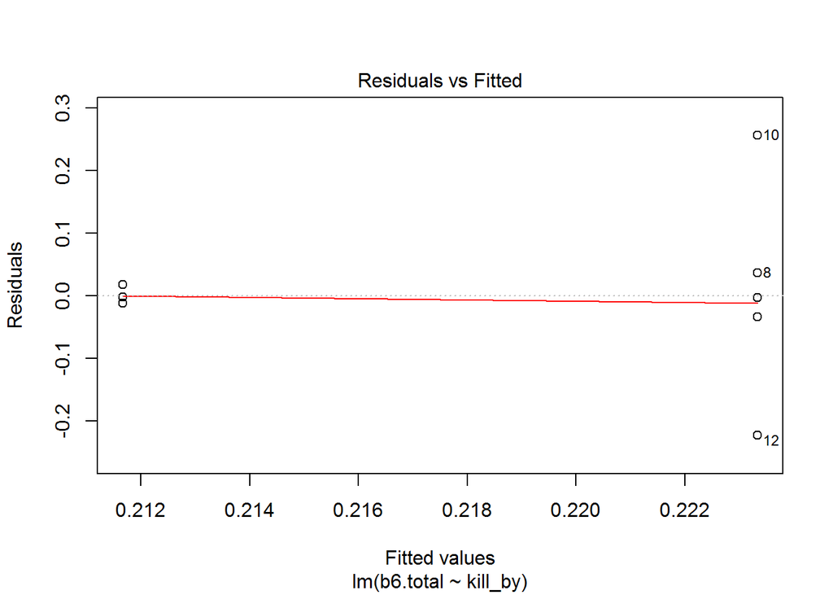

```r
plot(fit3, which = 1) # residual vs fitted values
```

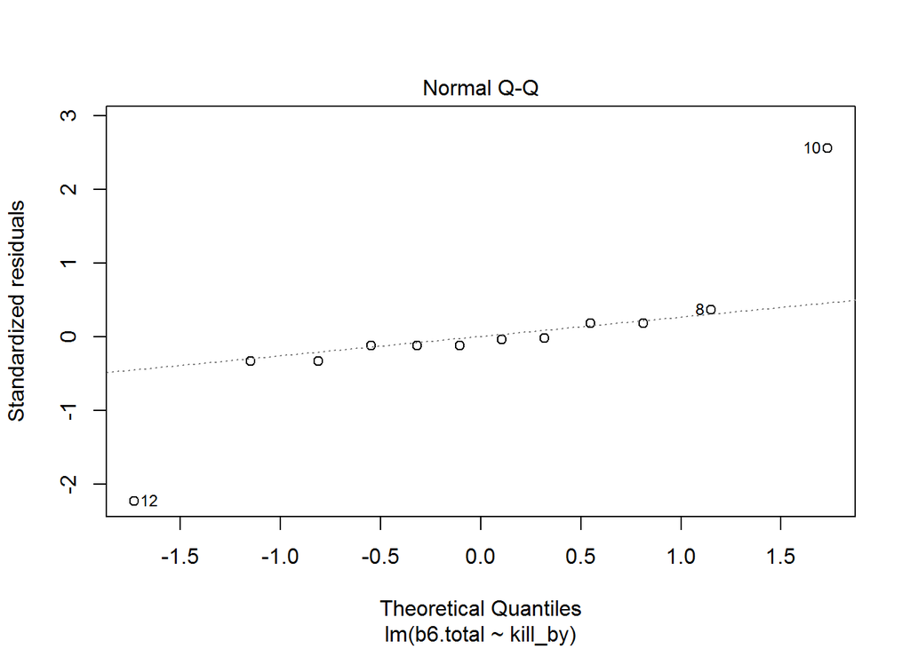

```r
plot(fit3, which = 2) # qqnorm plot of residuals
```

#### Model Summary

```r
summary(fit3)
```

```
##
## Call:
## lm(formula = b6.total ~ kill_by, data = pcf1)
##
## Residuals:
##      Min       1Q   Median       3Q      Max
## -0.22333 -0.01708 -0.00750  0.01833  0.25667
##
## Coefficients:
##             Estimate Std. Error t value Pr(>|t|)
## (Intercept)  0.21167    0.04480   4.725 0.000811 ***
## kill_byfire  0.01167    0.06336   0.184 0.857579
## ---
## Signif. codes:  0 '***' 0.001 '**' 0.01 '*' 0.05 '.' 0.1 ' ' 1
##
## Residual standard error: 0.1097 on 10 degrees of freedom
## Multiple R-squared:  0.00338,    Adjusted R-squared:  -0.09628
## F-statistic: 0.03391 on 1 and 10 DF,  p-value: 0.8576
```

```r
data.frame(summary(lsmeans(fit3, pairwise ~ kill_by),type = "response"))
```

```
##   lsmeans.kill_by lsmeans.lsmean lsmeans.SE lsmeans.df lsmeans.lower.CL
## 1          beetle      0.2116667 0.04479893         10        0.1118484
## 2            fire      0.2233333 0.04479893         10        0.1235151
##   lsmeans.upper.CL contrasts.contrast contrasts.estimate contrasts.SE
## 1        0.3114849      beetle - fire        -0.01166667   0.06335526
## 2        0.3231516      beetle - fire        -0.01166667   0.06335526
##   contrasts.df contrasts.t.ratio contrasts.p.value
## 1           10        -0.1841468         0.8575789
## 2           10        -0.1841468         0.8575789
```

#### t-test

```r
( respunequal = t.test(b6.total ~ kill_by, data = pcf1) )
```

```
##
##  Welch Two Sample t-test
##
## data:  b6.total by kill_by
## t = -0.18415, df = 5.0908, p-value = 0.861
## alternative hypothesis: true difference in means is not equal to 0
## 95 percent confidence interval:
##  -0.1736570  0.1503236
## sample estimates:
## mean in group beetle   mean in group fire
##            0.2116667            0.2233333
```

##### Table

Difference in means

```r
0.2116667-0.2233333
```

```
## [1] -0.0116666
```

g B6CA /BPCA

```r
# Write out the results from the two-sample t-test with unequal variances
# A title for the test
titleres = as.character(expression(bold("Welch"~t-test*~"for"~a~difference*~"in"~means)))
# This is the t stat with df and p-value
ttestres3 = as.character(expression(t[5.09]==-0.18*","~italic(p)==0.86))
# The estimated difference in group means (I calculated from the test results)
diff3 = as.character(expression(Delta==-0.012~g~B6CA~Total~BPCA^-1))
# The 95% CI of the difference
ci3 = as.character(expression(95*"%"~CI*":"~-0.17~to~0.15))
# Put these into a single column of a data.frame
d3 = data.frame(col = rbind(ttestres3, diff3, ci3) )
```

```r
t3 = tableGrob(d3, rows = NULL, cols = NULL,
theme = ttheme_default(core = list(bg_params = list(fill = "white"),
fg_params = list(parse = TRUE),
padding = unit(c(2.5, 2.5), "mm"))))
```

```r
t3 = gtable_add_grob(t3, grobs = rectGrob(gp = gpar(fill = NA, lwd = NA)),
t = 1, b = nrow(t3), r = ncol(t3), l = 1)
```

#### Graph

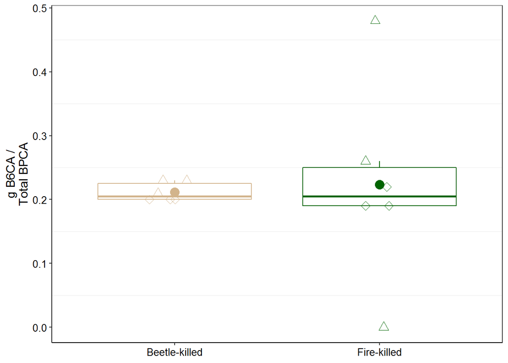

```r
g3 = ggplot(pcf1, aes(x = kill_by, y = b6.total, color=kill_by) ) + # define plot axes
  geom_boxplot(outlier.shape = NA) + # Add boxplots for each group
  geom_point(aes(color = kill_by, shape = bark.char), size = 3, position = position_jitter(w = 0.15, h = 0, seed=10)) +
stat_summary(fun = mean, geom= "point", size = 4) + # Add means to the plot
  scale_shape_manual(values = c(23, 24)) +
  labs(x=(NULL), y= "g B6CA /\nTotal BPCA") +

  scale_color_manual(values = c("tan", "darkgreen")) +

scale_x_discrete(labels= c("Beetle-killed", "Fire-killed")) +
  theme_bw() +
  theme(legend.position = "none") +
theme(panel.grid.major = element_blank()) +
    theme(axis.title.y = element_text(size = 12, hjust = 0.5, vjust = 1.1),
        axis.text.x = element_text(size = 10, color = "black"),
        axis.text.y = element_text(size = 10, color = "black"),
        axis.line = element_line(colour = "black"))


g3
```

## Manuscript figure

### Legend

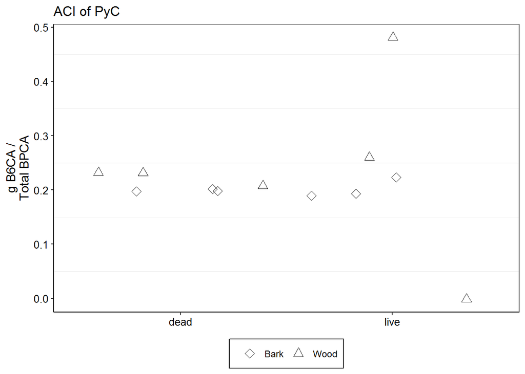

```r
legend_bottom = ggplot(pcf, aes(x = live.dead, y = b6.total)) +
  geom_jitter(aes(shape = bark.char), size = 3) +
  labs(title = "ACI of PyC", x=(NULL), y= "g B6CA /\nTotal BPCA") +
  scale_shape_manual(values = c(23, 24)) +
  theme_bw() +
  theme(legend.position = "bottom",
        legend.title = element_blank(),
              legend.text = element_text(size = 9)) +
  theme(legend.background = element_rect(colour = 'black', fill = 'white', linetype='solid')) +
theme(panel.grid.major = element_blank())+
    theme(axis.title.y = element_text(size = 12, hjust = 0.5, vjust = 1.1),
        axis.text.x = element_text(size = 10, color = "black"),
        axis.text.y = element_text(size = 10, color = "black"),
        axis.line = element_line(colour = "black"))

legend_bottom
```

```r
legend_b = get_legend(legend_bottom)
```

### Gridded boxplots

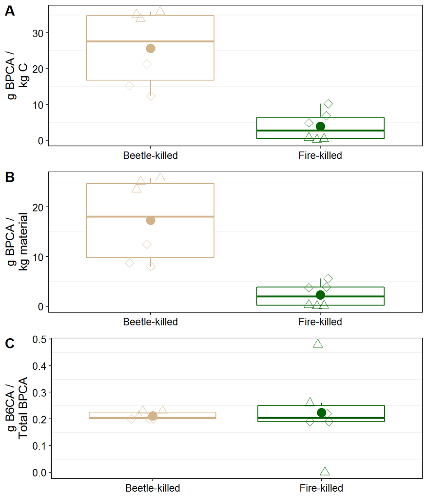

```r
p1 = cowplot::plot_grid(g1, g2, g3, labels = c("A", "B", "C"), ncol = 1)
p1
```

### Gridded with t-test data

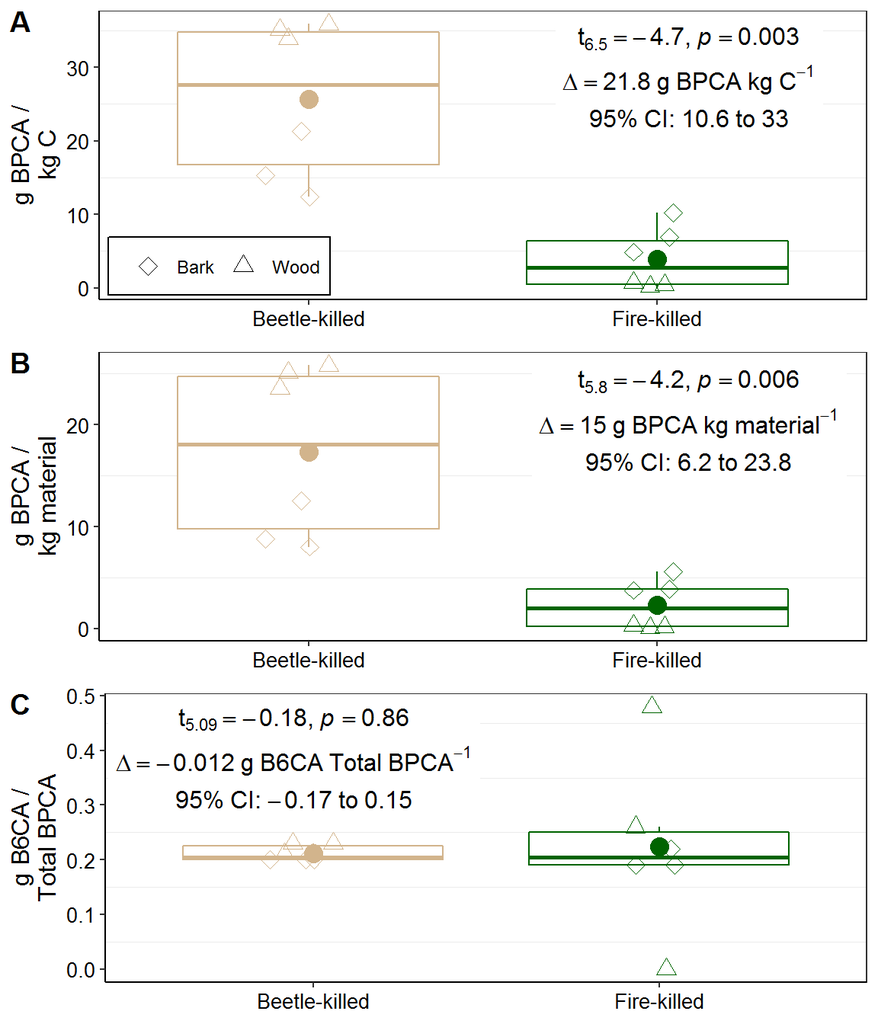

```r
p4 = p1 +
  draw_plot(legend_b, x =.10, y = .59, width = .3, height = .3) +
  draw_grob(t1,x =.66, y = .80, width = .25, height = .25, scale=.5) +
  draw_grob(t2,x =.66, y = .465, width = .25, height = .25, scale=.5) +
  draw_grob(t3,x =.21, y = .135, width = .25, height = .25, scale=.5)

p4
```

**THE END**